# chapter4

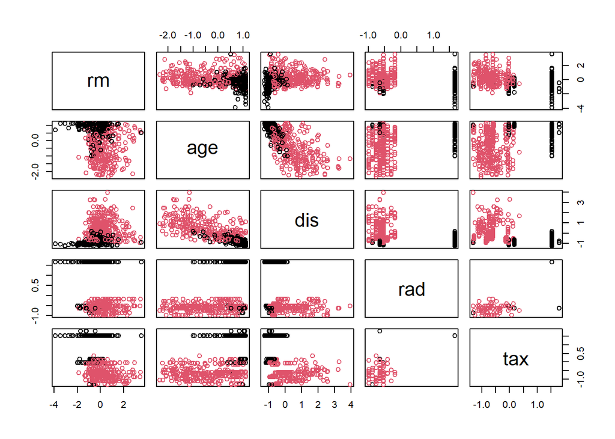

```r
pairs(scaled_boston[6:10], col = km$cluster)
```

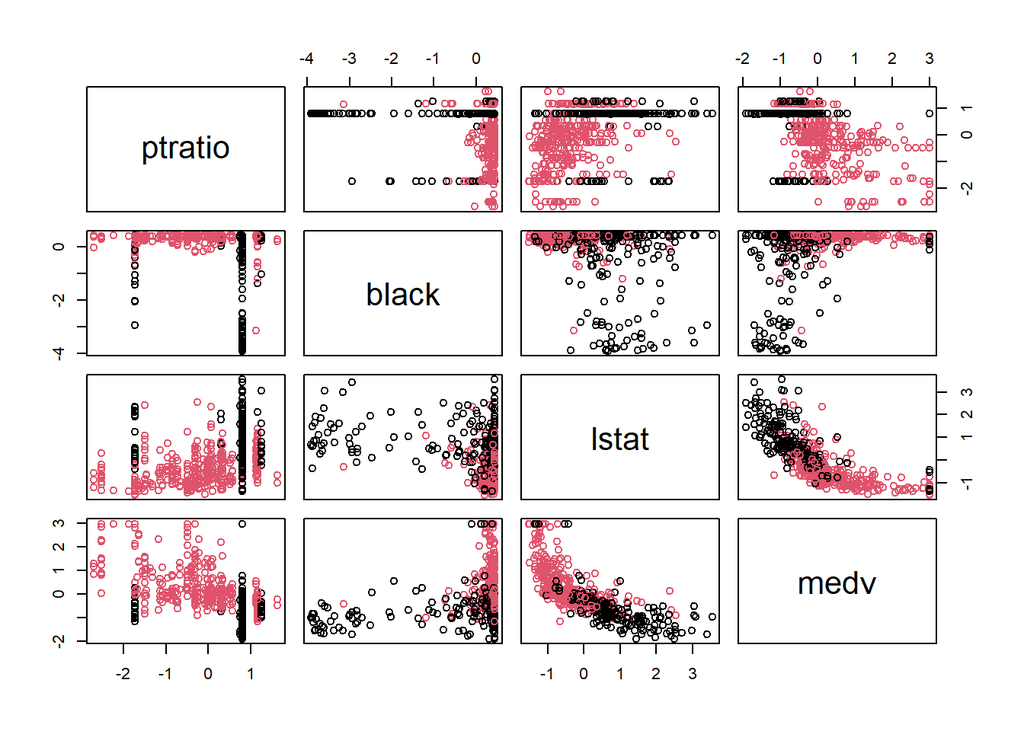

```r
pairs(scaled_boston[11:14], col = km$cluster)
```

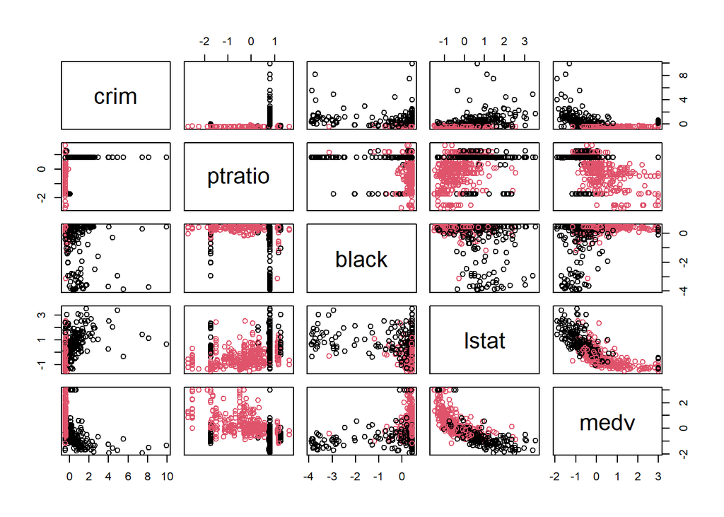

```r
pairs(scaled_boston[c(1,11,12,13,14)], col = km$cluster)
```

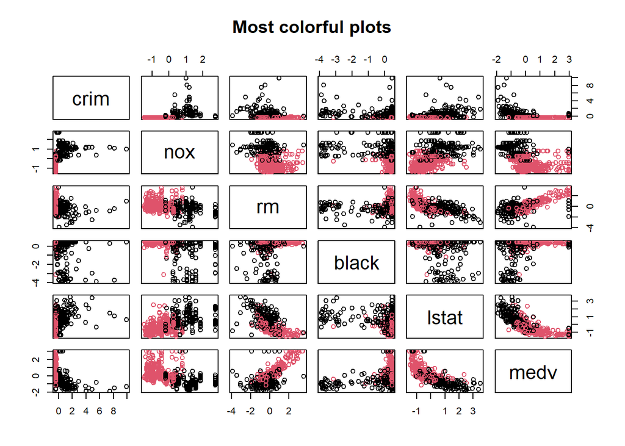

```r
pairs(scaled_boston[c(1,5,6,12,13,14)], col = km$cluster, main = "Most colorful plots")
```

When the amount of clusters is optimized (2 clusters), I can see clearer classification of observations into two groups in most of the figures.

### Bonus

```r
#I will use 3 klusters in the kmeans
set.seed(34)

data("Boston")
scaled_boston = as.data.frame(scale(Boston))



#k-means algorithm, 1. run:
km3 <- kmeans(scaled_boston, centers = 3)

#put the km3 clusters (or classification of individuals to these clusters) as covariate to the scaled Boston data:
clusters = km3$cluster
clusters_df = as.data.frame(clusters) #it seems that row numbers refer to the original row numbers and are already at the original order, so the dataframes can be combined just by using cbind

scaled_boston = cbind(scaled_boston, clusters_df)
str(scaled_boston)
```

```
## 'data.frame':    506 obs. of  15 variables:
##  $ crim    : num  -0.419 -0.417 -0.417 -0.416 -0.412 ...
##  $ zn      : num  0.285 -0.487 -0.487 -0.487 -0.487 ...
##  $ indus   : num  -1.287 -0.593 -0.593 -1.306 -1.306 ...
##  $ chas    : num  -0.272 -0.272 -0.272 -0.272 -0.272 ...
##  $ nox     : num  -0.144 -0.74 -0.74 -0.834 -0.834 ...
##  $ rm      : num  0.413 0.194 1.281 1.015 1.227 ...
##  $ age     : num  -0.12 0.367 -0.266 -0.809 -0.511 ...
##  $ dis     : num  0.14 0.557 0.557 1.077 1.077 ...
##  $ rad     : num  -0.982 -0.867 -0.867 -0.752 -0.752 ...
##  $ tax     : num  -0.666 -0.986 -0.986 -1.105 -1.105 ...
##  $ ptratio : num  -1.458 -0.303 -0.303 0.113 0.113 ...
##  $ black   : num  0.441 0.441 0.396 0.416 0.441 ...
##  $ lstat   : num  -1.074 -0.492 -1.208 -1.36 -1.025 ...
##  $ medv    : num  0.16 -0.101 1.323 1.182 1.486 ...
##  $ clusters: int  3 3 3 3 3 3 3 3 3 3 ...
```

```r
#clusters are added now as one variable

#LDA, clusters as target variable
#number of rows from which 80% and 20% sets are extracted
n <- nrow(scaled_boston)

# choose randomly 80% of the rows
#set seed to be able to get same results next time running this code
set.seed(34)
ind <- sample(n,  size = n * 0.8)

# create train set
train <- scaled_boston[ind,]

# create test set
test <- scaled_boston[-ind,]

# linear discriminant analysis
lda.fit <- lda(clusters~., data = train)

# print the lda.fit object
lda.fit
```

```
## Call:
## lda(clusters ~ ., data = train)
##
## Prior probabilities of groups:
##          1          2          3
## 0.34900990 0.08168317 0.56930693
##
## Group means:
##         crim         zn      indus        chas        nox         rm        age
## 1  0.1516016 -0.4872402  0.8730132  0.09066599  0.8062425 -0.4329048  0.7720703
## 2  1.8657952 -0.4872402  1.0149946 -0.27232907  0.9992416 -0.5112459  0.8021512
## 3 -0.3978017  0.4280935 -0.7561273 -0.04979732 -0.6691488  0.3722733 -0.5851541
##          dis        rad        tax    ptratio       black      lstat       medv
## 1 -0.7161339  0.5486036  0.6702466  0.4313402  0.07474274  0.5726428 -0.4730333
## 2 -0.8837717  1.6596029  1.5294129  0.8057784 -2.83988992  1.3014741 -1.1234848
## 3  0.6245909 -0.5849011 -0.6774806 -0.4242957  0.36438512 -0.5899528  0.4611350
##
## Coefficients of linear discriminants:
##                 LD1         LD2
## crim    -0.44604879 -0.71804874
## zn      -0.28861407  0.26036425
## indus   -0.53482830  0.66737012
## chas    -0.01142710  0.07852759
## nox      0.10707217  0.56271011
## rm       0.02938810 -0.18794156
## age     -0.24542626  0.36296679
## dis      0.35585977 -0.07389195
## rad      0.03148890 -0.44435474
## tax     -0.56303789  0.77167414
## ptratio -0.31394845  0.13712459
## black    1.43121658  1.23857167
## lstat   -0.34064416  0.02100824
## medv     0.01327656 -0.02959818
##
## Proportion of trace:
##    LD1    LD2
## 0.7939 0.2061
```

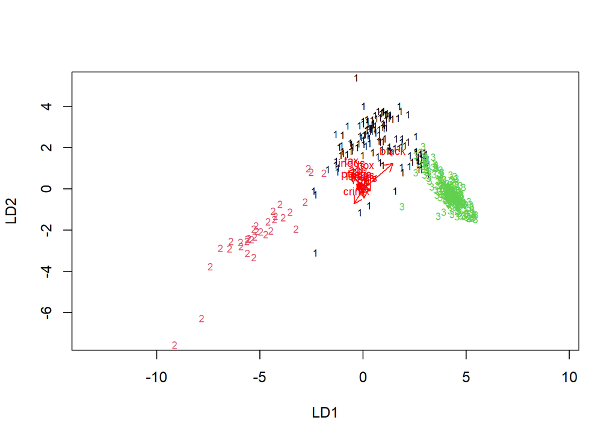

```r
# the function for lda biplot arrows
lda.arrows <- function(x, myscale = 1, arrow_heads = 0.1, color = "red", tex = 0.75, choices = c(1,2)){
  heads <- coef(x)
  graphics::arrows(x0 = 0, y0 = 0,
         x1 = myscale * heads[,choices[1]],
         y1 = myscale * heads[,choices[2]], col=color, length = arrow_heads)
  text(myscale * heads[,choices], labels = row.names(heads),
       cex = tex, col=color, pos=3)
}

# target classes as numeric
classes <- as.numeric(train$clusters)

# plot the lda results (select both lines and execute them at the same time!)
plot(lda.fit, dimen = 2, col = classes, pch = classes)
lda.arrows(lda.fit, myscale = 1)
```

Interpretation of Bonus biplot results: It is very difficult to see the names of variables in the plot, but I would interpret that the names at the tips of the longest opposite arrows indicate which of the variables are the most influential linear separators. Those two variables seem to be crim and black. Black I would have guessed based on the pairplots evalueated earlier, but crim was a little surprise for me. But the earlier pairplots including crim seem to represent quite clear two-class (at least) separation of observations.